# weather-project

Introduction

Project Inspiration

It is obvious to anyone that seasonal changes work hand-in-hand with tourism. With Malta being known for its hot sunny climate, it makes for an ideal destination spot for anyone looking for deep-rooted history and culture, traditional architecture, as well as its beautiful beaches.

However, it can also be noted that within the last decade, the number of tourists every summer has sky rocketed. Therefore, I wanted to know exactly WHY this increase has occurred. Is it because of Malta making a bigger name for itself internationally? Or is there another factor?

Upon thinking on this, as a Maltese citizen, it is clear that our summers have gotten drier and hotter, and rather than this deterring tourists, it has brought in an influx of them. Therefore, I wanted concrete correlative data finding the link between these weather conditions and tourists, and whether or not they have as much of an impact as I thought.

```
      mean_temp   max_temp  feels_like  sunshine_dur  daylight_dur  \
0     17.157497  18.857500   12.822860  34635.476562  35184.191406
1     15.365833  16.007500    7.778753  34146.585938  35220.207031
2     14.561668  15.107500    8.405110  33864.101562  35259.179688
3     14.834582  16.807501   11.814759  27727.416016  35301.085938
4     16.895000  18.107500   12.998100  30295.017578  35345.867188
...         ...        ...         ...           ...           ...
5839  15.510418  16.700001   12.891060  32277.310547  35051.183594
5840  14.535417  17.100000   13.406756  33581.242188  35071.515625
5841  13.752086  16.350000   13.152936  29120.347656  35094.996094
5842  13.564583  15.400000   11.221592  33344.414062  35121.636719
5843  13.343750  15.400000   10.727241  32398.789062  35151.402344

      precipitation  wind_speed  weather_code
0               0.0   43.601631           3.0
1               0.2   54.553955          51.0
2               0.0   45.424240           2.0
3               0.0   29.024128           3.0
4               0.0   36.546650           3.0
...             ...         ...           ...
5839            1.3   26.221373          53.0
5840            0.1   19.361507          51.0
5841            1.4   12.749540          53.0
5842            1.2   25.264202          53.0
5843            1.7   29.606031          53.0

[5844 rows x 8 columns]
```

```
     freq c_resid unit    nace_r2 geo\TIME_PERIOD  1990-01  1990-02  1990-03  \
1469    M   TOTAL   NR  I551-I553              MT      NaN      NaN      NaN

      1990-04  1990-05  ...   2025-05   2025-06   2025-07   2025-08   2025-09  \
1469      NaN      NaN  ...  258737.0  252970.0  265532.0  271574.0  245468.0

       2025-10   2025-11   2025-12   2026-01  2026-02
1469  283159.0  225437.0  205869.0  174318.0      NaN

[1 rows x 439 columns]
```

```
         mean_temp  max_temp  feels_like  sunshine_dur  daylight_dur  \
2010-01       13.8      18.9         8.9    260.265167    311.221917
2010-02       13.8      19.0         9.3    261.864583    304.836944
2010-03       14.4      18.3        11.1    315.765556    371.162278
2010-04       16.1      19.4        14.2    352.021778    393.274111
2010-05       18.5      24.2        16.6    385.540556    436.067917
...            ...       ...         ...           ...           ...
2025-08       26.5      32.3        29.6    388.778278    417.751806
2025-09       25.4      32.8        27.9    342.742056    371.764194
2025-10       21.4      26.9        21.3    309.080611    349.124889
2025-11       18.2      24.2        17.0    257.064333    308.276250
2025-12       15.3      20.4        13.7    247.401250    302.845306

         precipitation  wind_speed  weather_code    weather_desc
2010-01           56.8        41.2             3        Overcast
2010-02           22.9        40.3             3        Overcast
2010-03           41.7        33.9             3        Overcast
2010-04           11.0        29.0             3        Overcast
2010-05            2.9        31.7             3        Overcast
...                ...         ...           ...             ...
2025-08            1.0        16.0             0       Clear sky
2025-09           26.7        15.2             3        Overcast
2025-10           51.0        21.6             3        Overcast
2025-11           34.4        21.0            51  Drizzle: Light
2025-12           82.9        19.7             3        Overcast

[192 rows x 9 columns]
```

```
         tourist_arrivals
2010-01             49634
2010-02             65960
2010-03             84836
2010-04            104939
2010-05            123745
...                   ...
2025-08            271574
2025-09            245468
2025-10            283159
2025-11            225437
2025-12            205869

[192 rows x 1 columns]
```

```
         tourist_arrivals  mean_temp  max_temp  feels_like  sunshine_dur  \
2010-01             49634       13.8      18.9         8.9    260.265167
2010-02             65960       13.8      19.0         9.3    261.864583
2010-03             84836       14.4      18.3        11.1    315.765556
2010-04            104939       16.1      19.4        14.2    352.021778
2010-05            123745       18.5      24.2        16.6    385.540556
...                   ...        ...       ...         ...           ...
2025-08            271574       26.5      32.3        29.6    388.778278
2025-09            245468       25.4      32.8        27.9    342.742056
2025-10            283159       21.4      26.9        21.3    309.080611
2025-11            225437       18.2      24.2        17.0    257.064333
2025-12            205869       15.3      20.4        13.7    247.401250

         daylight_dur  precipitation  wind_speed  weather_code    weather_desc
2010-01    311.221917           56.8        41.2             3        Overcast
2010-02    304.836944           22.9        40.3             3        Overcast
2010-03    371.162278           41.7        33.9             3        Overcast
2010-04    393.274111           11.0        29.0             3        Overcast
2010-05    436.067917            2.9        31.7             3        Overcast
...               ...            ...         ...           ...             ...
2025-08    417.751806            1.0        16.0             0       Clear sky
2025-09    371.764194           26.7        15.2             3        Overcast
2025-10    349.124889           51.0        21.6             3        Overcast
2025-11    308.276250           34.4        21.0            51  Drizzle: Light
2025-12    302.845306           82.9        19.7             3        Overcast

[192 rows x 10 columns]
```

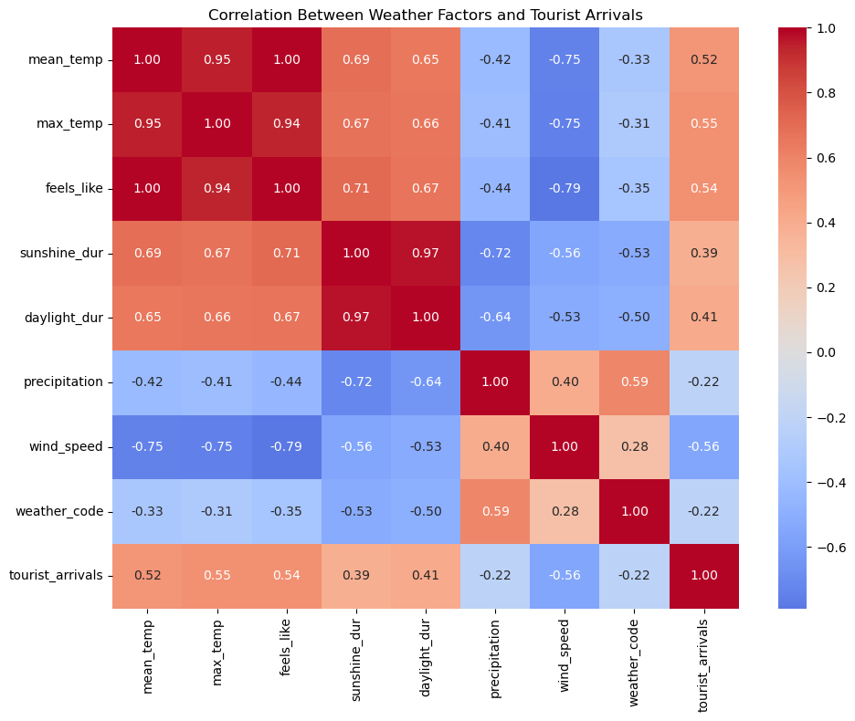

```
=== CORRELATION RESULTS ===

max_temp         0.545253
feels_like       0.538703
mean_temp        0.521722
daylight_dur     0.412457
sunshine_dur     0.389461
precipitation   -0.219104
weather_code    -0.219966
wind_speed      -0.555857
Name: tourist_arrivals, dtype: float64

=== LASSO REGRESSION RESULTS ===

         feature   coefficient
0      mean_temp   9905.283970
2   daylight_dur   5982.507408
3  precipitation   2037.868551
1   sunshine_dur     -0.000000
5   weather_code   -226.074359
4     wind_speed -20341.859643


sunshine_dur  has been dropped by Lasso.

Precipitation Stats

 count    192.000000
mean      32.660937
std       34.849282
min        0.000000
25%        3.300000
50%       23.350000
75%       50.525000
max      164.900000
Name: precipitation, dtype: float64
```

Result Analysis

Positive Trend Indicators

1. mean_temp

The strongest positive trend indicator was the 'mean_temp' feature, showing that approximately 10,000 more tourists come to Malta when temperatures are higher.

2. daylight_dur

The second strongest positive trend indicator was 'daylight_dur'. This shows that the duration of daylight is more influencial than the duration of sunshine.

3. precipitation

A surprising 'positive' trend indicator. This was deemed anomolous due to the illogical coefficient *(more rain bringing more tourists)* and its weak influence.

Impactless Features

Negative Trend Indicators

1. wind_speed

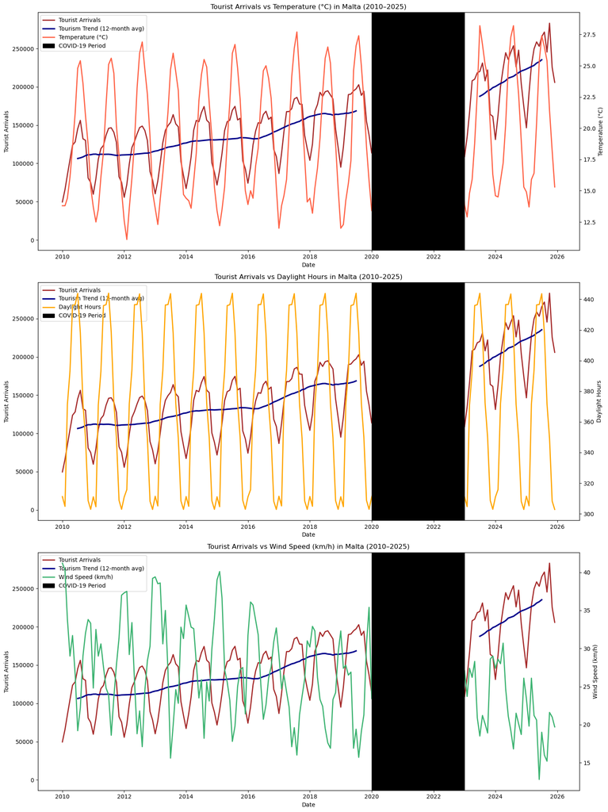

Result Analysis

Noticeable Considerations

**2020 - 2022 Tourism Dip**

Data from the 2020-2022 period was excluded from this visualisation to account for the tourism dip due to the COVID-19 pandemic. Removing this anomaly ensures that the visualisation remains consistent with long-term trends and consumer sentiment.

Expected Results

**mean_temp** and **daylight_hours** both provided the expected results. During colder months containing less daylight hours, tourism has a noticeable dip. This aligns with the preconceived notion of tourism peaking during the summer. Both of these features move proportionally with the **Tourist Arrivals**, confirming the positive coefficient made by the Lasso Regression model earlier on.

Unexpected Results

Alternatively, **wind_speed** shows a decline over this time period, sparking doubts regarding potential data inaccuracies. As Malta becomes an increasingly more popular tourist attraction over the years, there are 2 possible scenarios to be looked into:

1. **Data Measurement Inaccuracies**

This scenario implies that either changes in measurement methodology or data source rather than a genuine meteorological trend, supported by the structural break in between 2016 and 2018, which clearly shows that this is not a gradual decline caused by climate change. Furthermore, implying that this extreme negative correlation trend is purely coincidental (as wind speed decreased due to these inaccuracies, Malta's popularity rose - displaying an inversely proportional relationship).

```
         malta travel
2010-01            46
2010-02            31
2010-03            42
2010-04            55
2010-05            42
...               ...
2025-08            34
2025-09            22
2025-10            23
2025-11            27
2025-12            33

[192 rows x 1 columns]
```

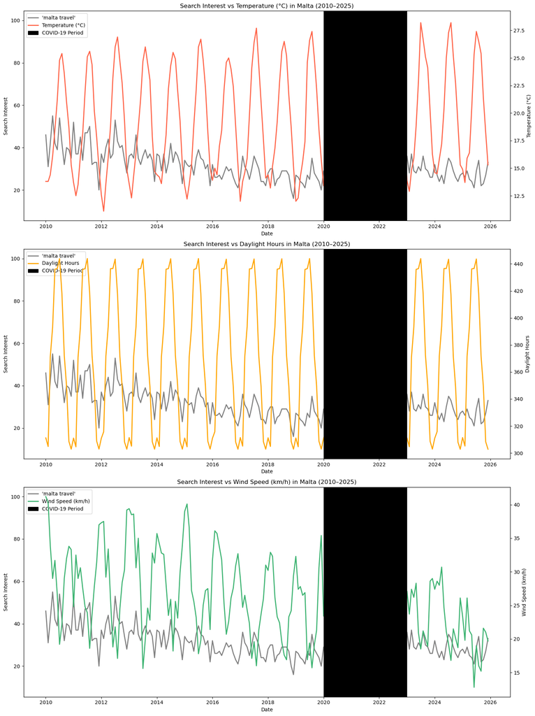

Result Analysis

However, **Search Interest** remains relatively consistent throughout the timeframe, with no noticeable long-term surges. This suggests that it captures seasonal patterns, rather than growing popularity.

Conclusions

Overall, the analysis suggests that weather conditions, particularly **temperature** and **daylight hours**, play a significant role in Malta's tourism patterns, with warmer sunnier months consistently attracting higher visitor numbers. This is further reinforced by Google Trends data, which shows search interest in Malta travel peaking slightly before the start of the warmer weather, suggesting that weather anticipation is a direct contributing factor during travel planning. The features **temperature** and **daylight hours** show consistent recordings throughout the years, and clear and consistent correlation patterns relative to the number of tourists. On the other hand, **wind speed** has the potential to be a deciding factor in tourist arrivals *if and only if* the data can be confirmed to be accurate.